# IDS 570 - Homework 1: Text Preparation

Tiye Ngachoko

2026-09-11

```r
library(readr)
library(dplyr)
library(tidyr)
library(stringr)
library(tidytext)
library(ggplot2)
library(forcats)
library(tibble)
library(scales)
```

```r
file_a <- "A07594__Circle_of_Commerce.txt"
file_b <- "B14801__Free_Trade.txt"

text_a <- read_file(file_a)
text_b <- read_file(file_b)

texts <- tibble(
  doc_title = c("Text A", "Text B"),
  text = c(text_a, text_b)
)

texts
```

```
## # A tibble: 2 × 2
##   doc_title text
##   <chr>     <chr>
## 1 Text A    THE CIRCLE OF COMMERCE. The Prooeme. HERODOTVS in his CLIO, reporte…
## 2 Text B    CAP. I. The Causes of the want of Money in England. IT hauing pleas…
```

```r
data("stop_words")

custom_stopwords <- tibble(
  word = c(
    "vnto", "haue", "doo", "hath", "bee", "ye", "thee"
  )
)

all_stopwords <- bind_rows(stop_words, custom_stopwords) %>%
  distinct(word)
```

## Part I: Diagnostics table

```r
# Tokenize WITHOUT removing stopwords yet
words <- texts %>%
  unnest_tokens(word, text) %>%
  mutate(word = str_to_lower(word))
```

```r
corpus_diagnostics <- words %>%
  count(doc_title, name = "total_tokens") %>%
  left_join(
    words %>%
      anti_join(all_stopwords, by = "word") %>%
      count(doc_title, name = "tokens_after_stopwords"),
    by = "doc_title"
  ) %>%
  mutate(
    tokens_removed  = total_tokens - tokens_after_stopwords,
    percent_removed = round(100 * tokens_removed / total_tokens, 1)
  )

corpus_diagnostics
```

```
## # A tibble: 2 × 5
##   doc_title total_tokens tokens_after_stopwords tokens_removed percent_removed
##   <chr>            <int>                  <int>          <int>           <dbl>
## 1 Text A           33894                  14697          19197            56.6
## 2 Text B           19924                   8005          11919            59.8
```

### Interpretive questions for Section I

- What percentage of each document was removed as stopwords?
- Is the percentage approximately the same for the two documents?
- What do these numbers tell you about how substantially stopword removal has transformed the texts you’ll be analyzing?

**Answer:**

Text A had 56.6% removed, and Text B had 59.8% removed. The two percentages are close, within about 3 percentage points, so I would assume stop-word removal affects both texts similarly, even though Text A is a lot longer overall (33,894 tokens compared to 19,924), the proportion taken up by other words is fairly comparable.From the list of stopwords removed, we can assume that both texts utilise a lot of function words.

## Part II: Most frequent words before vs. after stopword removal

### A. Before stopword removal

```r
word_counts_before <- words %>%
  count(doc_title, word, sort = TRUE)
```

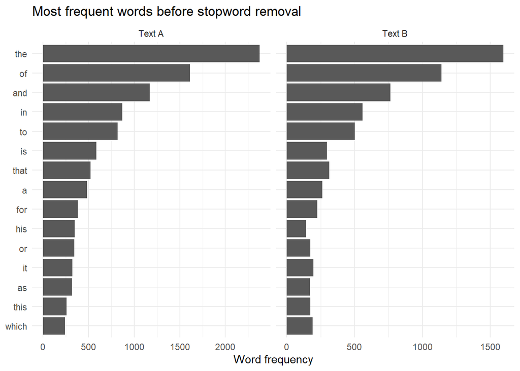

```r
plot_n_words <- 15

word_comparison_before <- word_counts_before %>%
  pivot_wider(
    names_from = doc_title,
    values_from = n,
    values_fill = 0
  ) %>%
  mutate(max_n = pmax(`Text A`, `Text B`)) %>%
  arrange(desc(max_n))

word_plot_data_before <- word_comparison_before %>%
  slice_head(n = plot_n_words) %>%
  pivot_longer(
    cols = c(`Text A`, `Text B`),
    names_to = "doc_title",
    values_to = "n"
  ) %>%
  mutate(word = fct_reorder(word, n, .fun = max))

ggplot(word_plot_data_before, aes(x = n, y = word)) +
  geom_col() +
  facet_wrap(~ doc_title, scales = "free_x") +
  labs(
    title = "Most frequent words before stopword removal",
    x = "Word frequency",
    y = NULL
  ) +
  theme_minimal()
```

### B. After stopword removal

```r
words_clean <- words %>%
  anti_join(all_stopwords, by = "word")

word_counts_after <- words_clean %>%
  count(doc_title, word, sort = TRUE)
```

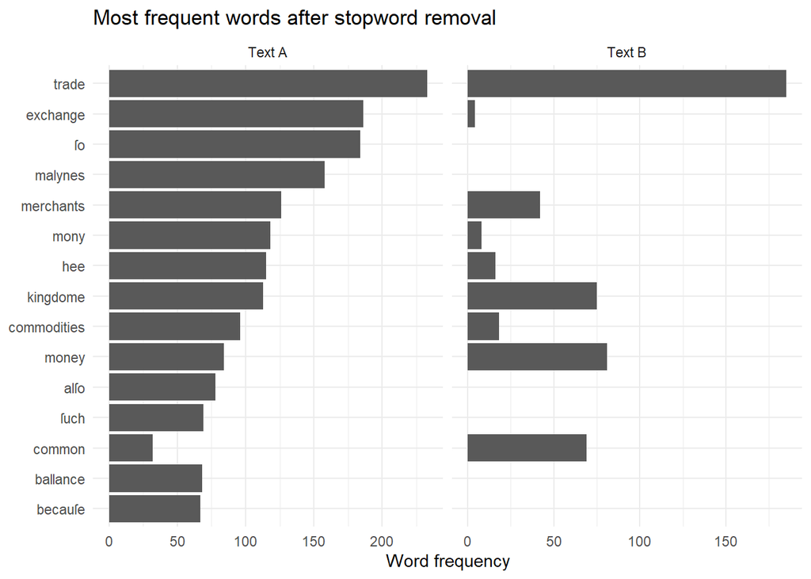

```r
word_comparison_after <- word_counts_after %>%
  pivot_wider(
    names_from = doc_title,
    values_from = n,
    values_fill = 0
  ) %>%
  mutate(max_n = pmax(`Text A`, `Text B`)) %>%
  arrange(desc(max_n))

word_plot_data_after <- word_comparison_after %>%
  slice_head(n = plot_n_words) %>%
  pivot_longer(
    cols = c(`Text A`, `Text B`),
    names_to = "doc_title",
    values_to = "n"
  ) %>%
  mutate(word = fct_reorder(word, n, .fun = max))

ggplot(word_plot_data_after, aes(x = n, y = word)) +
  geom_col() +
  facet_wrap(~ doc_title, scales = "free_x") +
  labs(
    title = "Most frequent words after stopword removal",
    x = "Word frequency",
    y = NULL
  ) +
  theme_minimal()
```

### Interpretive questions for Section II

- What dominates the frequency results before stopword removal?
- What becomes visible after stopword removal?
- Does removing stopwords make it easier to say something about the subject matter of these texts? Give at least two specific examples from your results.
- What information about the texts becomes less visible when we remove stopwords?

**Answer:**

I also notice what looks like a special character for s, in which these words are featured frequently in Text A, but not present at all in Text B. This might indicate the age or age of content in each text.

In Text A, after stopword removal, the word “malynes”, likely from the english economist, becomes very frequent. This reveals his significant presence in the subject matter of the text.

From what I can see, I’m not sure that we lose any valuable content/information through the stopword removal step.

## Part III: Testing the custom stopword list

```r
words_partial <- words %>%
  anti_join(stop_words, by = "word")

word_counts_partial <- words_partial %>%
  count(word, sort = TRUE)

word_comparison_partial <- words_partial %>%
  count(doc_title, word, sort = TRUE) %>%
  pivot_wider(
    names_from = doc_title,
    values_from = n,
    values_fill = 0
  ) %>%
  mutate(max_n = pmax(`Text A`, `Text B`)) %>%
  arrange(desc(max_n))

top15_partial <- word_comparison_partial %>%
  slice_head(n = 15)

top15_partial
```

```
## # A tibble: 15 × 4
##    word        `Text A` `Text B` max_n
##    <chr>          <int>    <int> <int>
##  1 trade            233      185   233
##  2 exchange         186        4   186
##  3 ſo               184        0   184
##  4 haue             163       86   163
##  5 malynes          158        0   158
##  6 merchants        126       42   126
##  7 mony             118        8   118
##  8 hee              115       16   115
##  9 kingdome         113       75   113
## 10 bee              108       51   108
## 11 commodities       96       18    96
## 12 hath              87       52    87
## 13 money             84       81    84
## 14 alſo              78        0    78
## 15 ſuch              69        0    69
```

## Final Reflection

*(In 3-5 sentences, respond to the following statement, using at least one specific result from your analysis as evidence:) “Stopword removal is just data cleaning. It doesn’t affect the interpretation because we are only removing unimportant words.”*

**Answer:** Stopword removal, cannot predict that all words removed are unimportant. Since stopwords are often the most common words featured in a text, if we were to simply remove the most common words every time we applied stopword removal, in the example of Text A, we might miss out on “malynes” who is directly relevant to the subject matter. Even part II exemplifies how the choice of stopword removal can influence what question can/ should be interrogated from the remaining tokens.